# Populations & Distributions

# Setup

```r
library(ggplot2) # plotting library

source("http://bit.ly/theme_pub") # Set custom plotting theme
theme_set(theme_pub())
```

# Population vs Sample

Population and Sample are two core concepts in probability and statistics. Both words have several meanings in the English language, but specific meanings in statistcs.

The [Statistical Population](https://en.wikipedia.org/wiki/Statistical_population) is a group of individuals or objects that is usually too numerous to observe and measure each individually.

The Statistical Sample (or mathemattically a Subset) is the smaller number of individuals or objects that we observe.

The goal of statistics is to make inferences about the **population** based on observations we can make about the **Sample**. Typically, this will be based on one or more observations.

# Distributions

Populations and samples have a distribution, which describes all of the observations about the population or sample. Test statistics also have distributions (e.g. $t$, $\chi^2$, $F$).

I like to think of a distribution as a histogram. In R we can very quickly generate sample distributions by randomly selecting numbers from a population distribution. There are many population distributions to chose from, but let’s take a look at a few of the most common:

| Distribution | Data Type | Example |
| --- | --- | --- |
| Gaussian | Continuous data | height or length |
| Poisson | Count data | seed or egg number |
| Binomial | Bernoulli or Boolean data | Allele (A or a) |

## Gaussian

The Gaussian distribution is probably the first distribution you learned about. It fits many kinds of continuous measurement data. The `rnorm()` function in R can be used to sample from a Gaussian distribution. Let’s take a look:

```r
?rnorm
```

Notice the 3 key parameters of rnorm:

- `n` – number of observations (sample size)
- `mean` – vector of means (of the population)
- `sd` – vector of standard deviations (of the populations)

We can use this to generate a random sample to visualize with qplot. Let’s imagine we catch 10 lizards and measure their tail lengths. We’ll create a model for a population mean of 20 and standard deviation of 2.

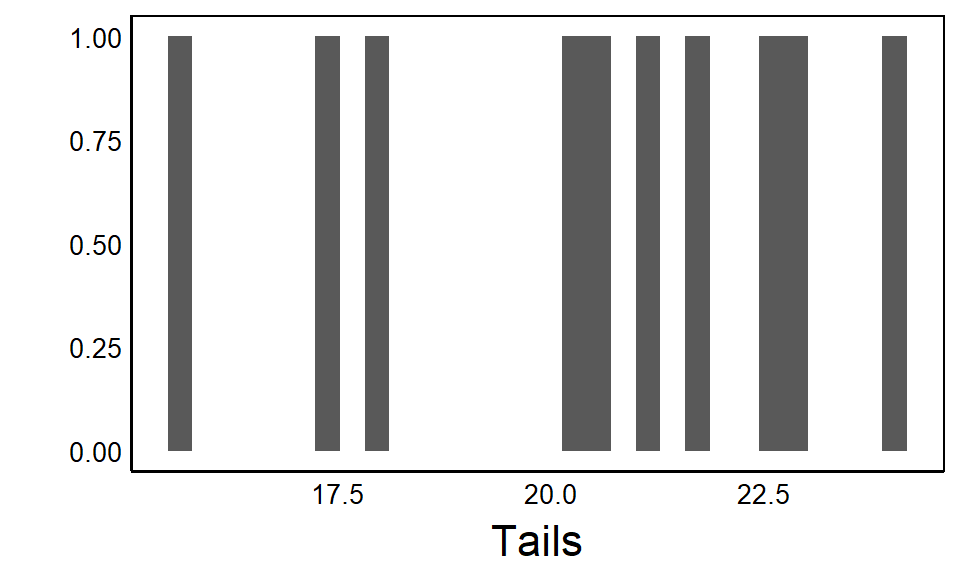

```r
Tails<-rnorm(n=10, mean=20, sd=2)
qplot(x=Tails)
```

Take a second to compare your graph with this one and you should see some differences. That’s because we’ve randomly sampled different individuals from the population. We’ll come back to this in the next section.

> Coding ProTip: you can use `set.seed` to always choose the same random sample

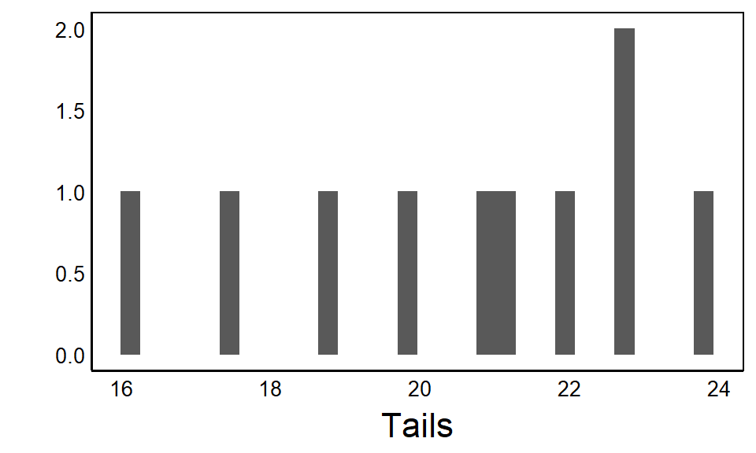

```r
set.seed(1234567890)
Tails<-rnorm(n=10, mean=20, sd=2)
qplot(x=Tails)
```

`set.seed` can be useful for troubleshooting and testing your code

Notice also in the description above that the `mean` and `sd` parameters are described as vectors. In our example we used a single value for each, representing a vector of length=1.

> What happens if you use a vector with > 1 element? e.g. c(20,0)

## Poisson

The Poisson distribution is common for count data, meaning that the sample will contain only whole numbers (no fractions/decimals) that are greater than or equal to zero. The `rpois` function draws from a Poisson distribution.

```r
?rpois
```

From the help file we can see two key parameters:

- `n` – number of observations (sample size; same as rnorm)
- `lambda` – vector of means (must be > 0)

Let’s simulate a sample of egg number from the same lizards we captured above

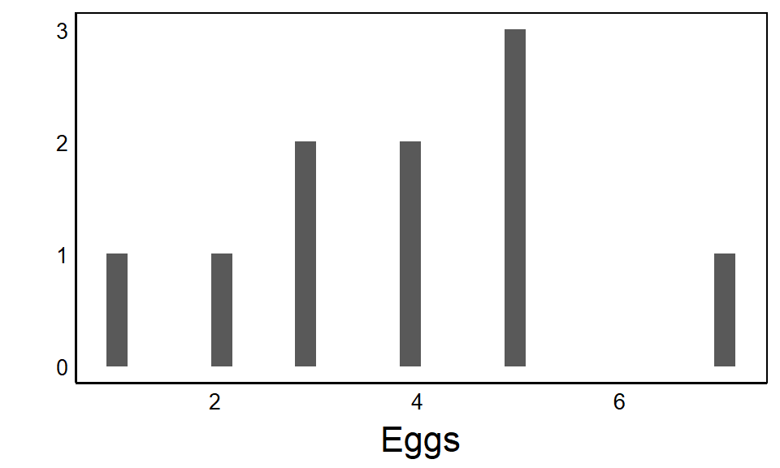

```r
Eggs<-rpois(n=10, lambda=4)
qplot(x=Eggs)
```

> What is the mean number of eggs per lizard in the population?

## Binomial

The binomial distribution describes a population of a Bernoulli or Boolean variable. The most popular example is the coin flip, but it is anything that can be encoded as true/false or 0/1.

The `rbin` function draws from a binomial distribution

```r
?rbinon
```

Here we see three parameters:

- `n` – number of observations (sample size, as above)
- `size` – number of trials
- `prob` – probability of success on each trial

What’s the difference between `n` and `size`? This is a bit tricky, and easier to explain with examples.

Imagine we again sample 10 lizards and check whether they are male or female. Let’s also say that the population has an equal sex ratio: 50% male and 50% female

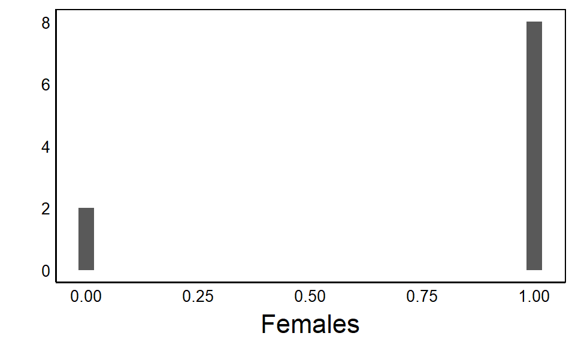

```r
Females<-rbinom(n=10, size=1, prob=0.5)
qplot(x=Females)
```

In this example, we set `size=1` because we are only sampling one lizard.

Now imagine that we want to sample only female lizards but then look at the embryos developing in their eggs to determine if they are male or female. We’ll sample 5 eggs per female.

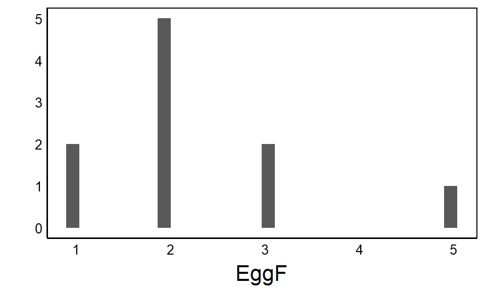

```r
EggF<-rbinom(n=10, size=5, prob=0.5)
qplot(x=EggF)
```

> How would you model this if there were 60% females and 40% males?

Compare the two binomial graphs carefully. What is different and why? Looking at the raw data can help to understand this:

```r
head(Females)
```

```
## [1] 1 0 1 1 1 0
```

```r
head(EggF)
```

```
## [1] 3 2 2 2 2 5
```

```r
str(Females)
```

```
##  int [1:10] 1 0 1 1 1 0 1 1 1 1
```

```r
str(EggF)
```

```
##  int [1:10] 3 2 2 2 2 5 3 1 2 1
```

In the first case, we are sampling 10 lizards to check whether they are female. These data are boolean (1/0 or true/false). When we plot them, we get a frequency histogram showing the proportions of 1 and 0.

In the second case, we are sampling 5 eggs **and then counting** how many are female. These data are count data similar to the Poisson distribution except that we can’t have more than 5.

# Distribution Metrics

In addition to visualizing our sample distributions as histograms, we can calculate some basic characteristics about our distributions. These parameters can describe the distribution of our entire **population** or the distribution of a particular **sample** drawn from the population. The equations are similar so we need to use different symbols to make it clear whether we mean the sample or the population. We’ll use this convention:

| Metric | Sample Symbol | Population Symbol |
| --- | --- | --- |
| Individual | $x_i$ | $x_i$ |
| Mean | $\bar x$ | $\bar X$ |
| SD | $s$ | $\sigma$ |

## Mean

The sample mean is the average value, calculated by adding up all of the individual observations ($x_i$) and dividing by the number of observations ($n$).

$$\bar x = \frac{ \sum x_i }{n}$$

```r
mean(Tails)
```

```
## [1] 20.55558
```

```r
mean(Eggs)
```

```
## [1] 3.9
```

```r
mean(Females)
```

```
## [1] 0.8
```

```r
mean(EggF)
```

```
## [1] 2.3
```

## Standard Deviation

The standard deviation $s$ of a sample is just the square-root of the variance $s^2$, and it describes how much the data spreads out away from the mean. The variance takes each value $x_i$ and subtracts the mean $\bar x$. Then it adds all of these values together and divides by the sample size minus 1.

$$s^2 = \frac{ \sum x_i - \bar x }{n - 1}$$

## Coefficient of Variation

The coefficient of variance $C_V$ (aka relative standard deviation, RSD) is simply the standard deviation divided by the mean. This can be useful because the variance of a sample often scales with the mean. Often this is multiplied by 100%, though this isn’t always the case.

$$C_V = \frac{s}{\bar x} \times 100\%$$

> TIP: Don’t get tripped up by the math. You’ve learned it before and R has functions to quickly calculate these paramters

# Central Limit Theorem

What is the relationship between the distribution of a **population** vs the distribution of a **sample**? Let’s go back to our lizard tail data.

```r
set.seed(25)
Tails<-rnorm(n=10, mean=20, sd=2)
```

In this code the mean of our **population** is 20 and the standard deviation of our population is 2. What is the mean and standard deviation of our sample?

```r
mean(Tails)
```

```
## [1] 19.65125
```

```r
sd(Tails)
```

```
## [1] 1.884406
```

What happens as we increase our sample size?

```r
set.seed(25)
Tails<-rnorm(n=100, mean=20, sd=2)
mean(Tails)
```

```
## [1] 19.63568
```

```r
sd(Tails)
```

```
## [1] 2.012269
```

```r
set.seed(25)
Tails<-rnorm(n=1000, mean=20, sd=2)
mean(Tails)
```

```
## [1] 20.0074
```

```r
sd(Tails)
```

```
## [1] 2.001422
```

```r
set.seed(25)
Tails<-rnorm(n=1000, mean=20, sd=2)
mean(Tails)
```

```
## [1] 20.0074
```

```r
sd(Tails)
```

```
## [1] 2.001422
```

The Central Limit Theorem describes this phenomenon. As our sample size increases our sample distribution approaches our population distribution.

## Standard Error

All of the above metrics ($\bar x$, $s$, $C_v$) are measured directly on the sample.

The standard error (SE), aka the standard error of the mean (SEM) is can also be calculated from the observed sample data, but it also takes advantage of the Central Limit Theorem to estimate a predicted range for the population mean of a Gaussian distribution.

$$SE = \frac{s}{\sqrt N}$$
## Confidence Interval

The confidence interval (CI) is a range of two values (high/low) that we predict should include the population mean.

For a Gaussian distribution, the population mean $\bar X$ has a 95% chance of falling within +/- 1.96 SE of the sample mean

$$CI = \bar x \pm 1.96 \times SE$$

I get confused by math, but I find it easier to understand when you code it in R.

Let’s do one with a small sample size. And another with a large sample size:

```r
set.seed(25)
N<-10
Tails<-rnorm(n=N, mean=20, sd=2)
x<-mean(Tails)
sd<-sd(Tails)
se<-sd/sqrt(N)
CI<-c(x-1.96*se, x+1.96*se)
print(CI)
```

```
## [1] 18.48328 20.81921
```

```r
CI[2]-CI[1]
```

```
## [1] 2.335934
```

Now we could set N to 10,000 and re-run the code above:

```
## [1] 19.95497 20.03342
```

```
## [1] 0.07844591
```

> Compare the mean, sd, SE and CI for the two different sample sizes, and the population mean and sd (in the rnorm function)

# Sample Probability

Sometimes we want to test an observation against an expected distribution. For example, what if we find a new lizard with a tail length of 32.4 and we want to calculate the probability that this lizard came from the study population?

We know tail lengths in our lizard species are normally distributed with a mean of 20 and sd of 2.

One way is to look at the distribution of a very large sample size and compare it to the observed value. We can plot this value onto the histogram with `geom_line` or `geom_vline` in the `ggplot` library:

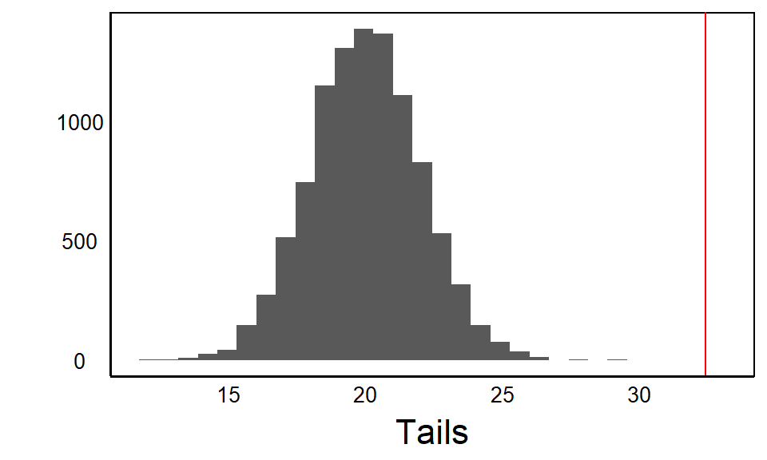

```r
qplot(x=Tails) + geom_vline(xintercept=32.4, colour="red")
```

The probability is just the area under the sample distribution that includes the observed value. The specific calculation depends on our hypothesis.

## z-score

A more common way to do this is to transform the data to **z-scores**. The **z-distribution** is a Gaussian distribution with a mean of zero and standard deviation of 1. Let’s say we sample 1,000 of our lizard population, and then standardize the tail lengths to z-scores, which is a simple equation:

$$z_i = \frac{x_i-\bar x}{s}$$

In other words, to calculate the z-score for each individual $z_i$ :

1. Calculate the mean $\bar x$ and sd $s$ of the sample
2. Subtract the mean from each observation $x_i$
3. Divide by the standard deviation

Here is the raw data for this sample population:

```r
N<-1000
Tails<-rnorm(n=N, mean=20, sd=2)
x<-mean(Tails)
sd<-sd(Tails)
se<-sd/sqrt(N)
CI<-c(x-1.96*se, x+1.96*se)
print(CI)
```

```
## [1] 19.82252 20.06620
```

```r
CI[2]-CI[1]
```

```
## [1] 0.2436768
```

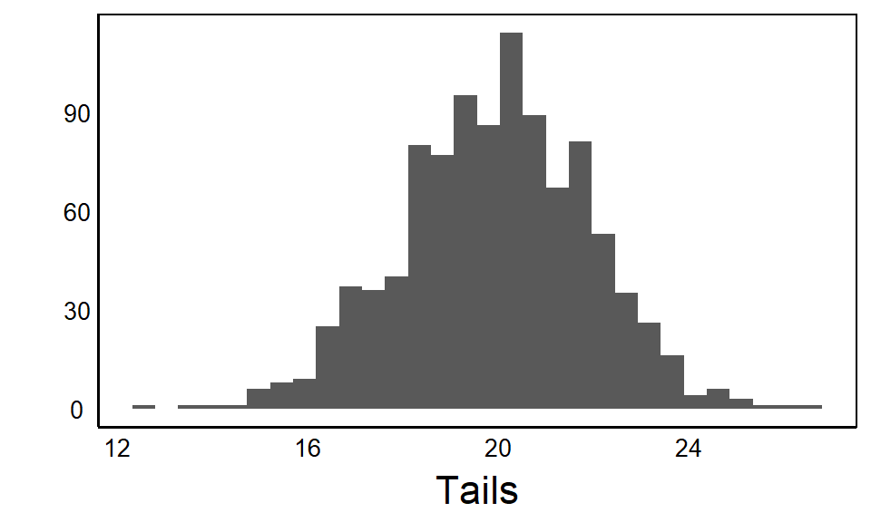

```r
qplot(Tails)
```

And the z-scores:

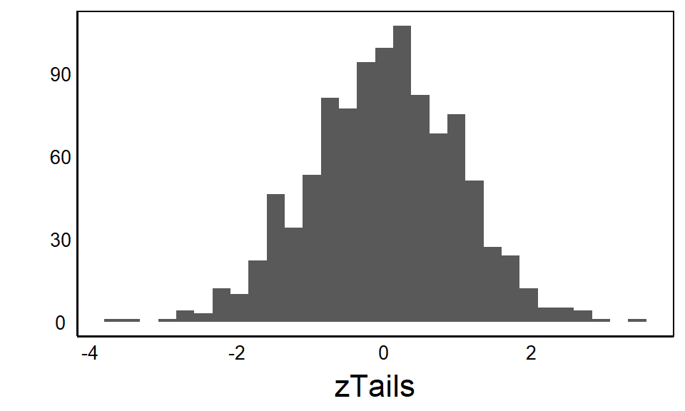

```r
zTails<-(Tails-mean(Tails))/sd(Tails)
qplot(zTails)
```

> Make sure to subtract the mean before dividing by sd

Now if we want to test whether the lizard with tail length 32.4 comes from the same population as our sample, we have to transform 32.4 to a z-score using the sample mean and sd:

```r
zLiz<-(32.4-mean(Tails))/sd(Tails)
print(zLiz)
```

```
## [1] 6.336333
```

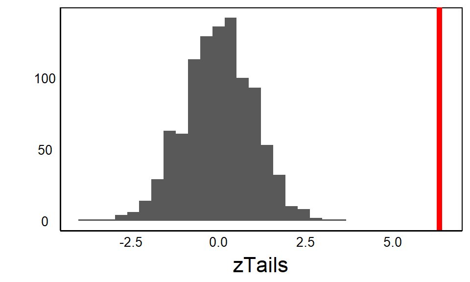

```r
qplot(zTails) + geom_vline(xintercept=zLiz,colour=I("red"),size=I(2))
```

Visually this looks like good evidence for a different species since there is no visible overlap with the study sample. But we also know that the human brain is always trying to find patterns, so we need a more formal test. There are two options here depending on our hypothesis.

## 2-tail test

The 2-tail test simply asks whether the observed value is different than we would expect from a random sample of the study population. It does not make a prediction about whether the value would be higher or lower.

$H_0 =$ The observation is NOT DIFFERENT from the population

## 1-tail test

The 1-tail test requires a directional prediction, for example, what is the probability that this sample is larger than expected from a random sample of the study population.

$H_0 =$ The observation is NOT BIGGER than the population

OR

$H_0 =$ The observation is NOT SMALLER than the population

> The difference between a 1-tail and two-tail test is usually achieved by mutliply/dividing the p-value by 2

## pnorm

Calculating the area under a Gaussian curve is easy to do in R, by using the `pnorm` function:

```r
?pnorm
```

Note the different parameters compared to rnorm. The key differences are:

- `lower.tail` – provides a probability that the observed value is lower (`TRUE`) or higher (`FALSE`) than expected by chance
- `q` – the vector of quantiles. This is just the vector of the observations that we wish to test. We can do this with z-scores or the original data:

```r
pnorm(q=32.4, mean=mean(Tails) ,sd=sd(Tails), lower.tail=F)
```

```
## [1] 1.176492e-10
```

```r
pnorm(q=zLiz, mean=0, sd=1, lower.tail=F)
```

```
## [1] 1.176492e-10
```

Since our observed value was great than the mean, we use `lower.tail = F`

The value is a probability ranging from 0 to 1.

> EXERCISE: Try changing sd and q to understand how the probability changes depending on the variance of the population and the difference between the observation and the population mean

Now, what if we have two or more samples of lizards and we want to see whether they came from the same population?

We need a test statistic.

Test statistics are calculated from a sample in order to test a specific hypothesis.

Some common statistics include $t$ for Student’s t-test, $\chi ^2$ for the goodness-of-fit test, and $F$ for ANOVA and regression.

# Student’s t

The t-test is a common statistical test and comes in two flavours:

## One-sample t-test

The one-sample t-test allows us to test whether a sample differs significantly from a defined mean. In our case, we might have captured 100 lizards and we want to know if they came from the species with a mean tail length of 20.

The $t$ statistic just compares the sample mean $\bar x$ with the population mean $\mu$.

$$t = \frac {\bar x - \mu}{SE_x}$$

Notice the similarity to the z-score calculation above, but instead of a z-score for each individual, we calculate a single $t$ value for the sample. Also, we divide by the standard error of the 100 test lizards rather than the standard deviation of of the 10,000 sample of lizards from the popualtion.

The one-sample t-test is particularly useful when you know the population mean but you don’t know the population variance. For example, if we wanted to test whether a weight-loss strategy is successful, or whether the presence of a predator alters behaviour of a prey. If our expected mean is zero then t simplifies to the sample mean divided by the standard error.

This equation solves another problem with the z-score example above: we need a very large sample size to accurately characterize the mean and sd of our study population. If we know the mean but not the sd, then the t-test can be used.

The final step is to compare the observed t-value against the range of values we would expect from a randomly drawn sample.

## Two-sample t-test

The two-sample t-test compares the means of two samples (e.g. $x$ and $y$), to test the null hypothesis that:

$H_0 = $ Sample $x$ and sample $y$ are randomly sampled from the same population

Instead of comparing one mean to a null expectation, we compare the two means to each other. Which standard error do we use? Both!

$$t = \frac{\bar x -\bar y}{\sqrt{(SE_x)^2 + (SE_y)^2}}$$

# Statistical Distributions

So far we have looked at sample distributions and population distributions. They are both defined by similar math (e.g. mean and sd) and can be plotted as histograms. Statistical distributions are another type of distribution based on expected values from random draws. In the old days, we would compare our observed $t$ to a table of $t$ values to calculate a p-value. Today we can do this faster and more accurately in statistical software. In R we can use the `t.test` function.

The first thing we should do is carefully read the help in R and look at the key parameters:

```r
?t.test
```

Notice that we have vectors of data `x` and `y` (optional) as well as `mu` ($\mu$), which is the mean for the one-sample test or the difference in means for the two-sample test. Notice that the default for `mu` is set to zero.

One other important parameter is `alternative`, which is analogous to the one-tailed and two-tailed tests used with the z-scores above.

Let’s create two vectors of data to use with the `t.test` function:

```r
Species1<-c(20,15,17,23,19,15)
Species2<-c(23,20,32,18,24,32)
```

## One-sample t

We can use this to separately test whether each species came from the population (i.e. species) with a mean tail length of 20

```r
t.test(x=Species1, mu=20)
```

```
##
##  One Sample t-test
##
## data:  Species1
## t = -1.437, df = 5, p-value = 0.2102
## alternative hypothesis: true mean is not equal to 20
## 95 percent confidence interval:
##  14.88701 21.44633
## sample estimates:
## mean of x
##  18.16667
```

```r
t.test(x=Species2, mu=20)
```

```
##
##  One Sample t-test
##
## data:  Species2
## t = 1.9908, df = 5, p-value = 0.1031
## alternative hypothesis: true mean is not equal to 20
## 95 percent confidence interval:
##  18.59235 31.07431
## sample estimates:
## mean of x
##  24.83333
```

Let’s take a second to look carefully at the output. It specifies what data we use, the caclulated t-value, degrees of freedom (N-1) and the p-value.

It also gives us the confidence interval and the mean of the sample. Notice that the 95% confidence interval overlaps our population mean $\mu$ when the p-value is not significant.

## Two-sample t

We can use the two-sample t to test whether the two samples came from the same statistical population:

```r
t.test(x=Species1, y=Species2)
```

```
##
##  Welch Two Sample t-test
##
## data:  Species1 and Species2
## t = -2.4307, df = 7.5659, p-value = 0.04284
## alternative hypothesis: true difference in means is not equal to 0
## 95 percent confidence interval:
##  -13.0549973  -0.2783361
## sample estimates:
## mean of x mean of y
##  18.16667  24.83333
```

Compare the output with the one-sample tests. Note the **Welch** in the title. This indicates an adjustment, which we can see if we search the help file. That is why the degrees of freedom (df) is not a whole number.

## Paired t-test

Sometimes our data can be paired in some way. For example, we might apply two different treatments to the same individual, or we might pair two individuals from the same family, class or group. In our lizard example, we might take a male and female egg from each mother and then see if their tail lengths differ. Let’s make a sample dataset for 6 mothers, each with one female and one male offspring:

```r
TLen<-data.frame(Mother=c("a","b","c","d","e","f"), # Code for unique mother
                 mLen=c(28,30,15,12,19,22), # Tail length of son (male)
                 fLen=c(30,29,17,16,23,26)) # Tail length of daughter (female)
str(TLen)
```

```
## 'data.frame':    6 obs. of  3 variables:
##  $ Mother: chr  "a" "b" "c" "d" ...
##  $ mLen  : num  28 30 15 12 19 22
##  $ fLen  : num  30 29 17 16 23 26
```

Note the special setup of this dataframe: each row is a different maternal lizard.

Again we use the `t.test` function, but this time we specify `paired=true`

```r
t.test(x=TLen$mLen,y=TLen$fLen,paired=T)
```

```
##
##  Paired t-test
##
## data:  TLen$mLen and TLen$fLen
## t = -3.1009, df = 5, p-value = 0.02683
## alternative hypothesis: true difference in means is not equal to 0
## 95 percent confidence interval:
##  -4.5724693 -0.4275307
## sample estimates:
## mean of the differences
##                    -2.5
```

Compare to the unpaired, two-sample t-test:

```r
t.test(x=TLen$mLen,y=TLen$fLen,paired=F)
```

```
##
##  Welch Two Sample t-test
##
## data:  TLen$mLen and TLen$fLen
## t = -0.66072, df = 9.7079, p-value = 0.5242
## alternative hypothesis: true difference in means is not equal to 0
## 95 percent confidence interval:
##  -10.965202   5.965202
## sample estimates:
## mean of x mean of y
##      21.0      23.5
```

Why such a big difference in p-value? Let’s compare the groups:

```r
mean(TLen$mLen) # mean males
```

```
## [1] 21
```

```r
sd(TLen$mLen)/sqrt(length(TLen$mLen)) # SE males
```

```
## [1] 2.898275
```

```r
mean(TLen$fLen) # mean females
```

```
## [1] 23.5
```

```r
sd(TLen$fLen)/sqrt(length(TLen$mLen)) # SE females
```

```
## [1] 2.43242
```

The means are different, but the confidence intervals overlap. This is because individual lizards vary a lot in the size of offspring. A paired t-test accounts for the variation among lizards before testing for a difference in the mean between male and female eggs.

# Assumptions

Every statistical test has assumptions. It’s important to know these assumptions and to make sure your data conform to the assumptions, otherwise your p-value can be meaningless.

A key assumption for the t-test is that the population follows a Gaussian distribution. We know this is true for data created with `rnorm` but we don’t know if it’s true for most real-world data.

There are many reasons and examples of real-world data violating these assumptions, and we can characterize some of this using central moments.